# ML_2_Summary

## Lasso Regression

Author: Jill Van den Dungen

### Summary/description:

Lasso is an alternative to the ridge regression. The cost function for lasso regression is RSS + λ * abs(slope). Here, the penalty term is determined by the absolute value of the coefficients instead of the square. This has the effect of forcing some of the coefficients estimates to be exactly equal to zero when the tuning parameter lambda is sufficiently large. Therefore, some variables are eliminated. Models generated from lasso are sparse = they are easier to interpret than the models by ridge regression.

### When to employ this method/model:

Use lasso when we suspect that the model includes a lot of useless features.

### Model Code and Inputs:

```r
#Create the train (75%) and test (25%) data sets
train<-sample(1:nrow(x), nrow(x)*0.75)
test<- (-train)
y_test=y[test]

#Create a lamba grid vector of 120 elements ranging from 10^10 to 10^-3
grid=10^seq(10,-3,length=120)

#Using the glmnet() function, create a lasso model named mod.lasso that predicts the training y's using the training x's and the grid of lambda values created above.

mod.lasso<-glmnet(x[train,],y[train],alpha = 1,lambda = grid)
```

### Model Tests:

```r
#Evaluate training model performance using cross-validation
#Using the cv.glmnet() function and the same parameters used above in the creation of mod.lasso (i.e. including the lambda grid vector),
#     create a 12-fold cross-validation model named cv.out.lasso

cv.out.lasso<-cv.glmnet(x[train,],y[train],alpha = 1,lambda = grid, nfolds=12)
plot(mod.lasso)
```

### Model Improvements:

```r
#Display the best cross-validated lambda value (the one that produces the lowest deviance - do not use the 1-standard error rule here).
bestlam<-cv.out.lasso$lambda.min

#Using the best lambda and the model named mod.lasso, create a vector of test set predictions.
lasso.pred<- predict(mod.lasso, s=bestlam, newx= x[test,])

#Compute and display the test error rate.
mean((lasso.pred-y_test)^2)
```

### Comprehensive Example:

```r
library(ISLR)
data(Hitters)
Hitters <- na.omit(Hitters)
#Using the hitters data set, we set up the "x" and "y" matrix values so that we can use the glmnet function.
x=model.matrix(Salary~., data=Hitters)[,-1]
y=Hitters$Salary

#Make a grid of lambda values
grid=10^seq(10,-2,length=100)

#Create test and train
set.seed(1)
train<-sample(1:nrow(x),nrow(x)/2)
test=(-train)
y.test=y[test]

#Create lasso model using train set
lasso.mod<-glmnet(x[train,],y[train], alpha=1, lambda= grid)
plot(lasso.mod)

#Create cross validation model
set.seed(1)
cv.out<-cv.glmnet(x[train, ], y[train], alpha=1)
plot(cv.out)

#Create best lambda and make predictions
bestlam<- cv.out$lambda.train
bestlam

lasso.pred<-predict(lasso.mod, s=bestlam, newx= x[test,])
mean((lasso.pred-y.test)^2)

#explore whole data set to see what best lambda is
out=glmnet(x,y,alpha= 1, lambda= grid)
lasso.coef<- predict(out, type= 'coefficients', s=bestlam)[1:20,]
lasso.coef
```

## Principal Component Regression

Author: Alex King

### Summary/description:

Principal Components Analysis (PCA): Popular Algorithm for deriving a low-dimensional set of features from a large set of features from a large set of variables. This is done by transforming X features through linear combinations

There are two methods:

Principal Components Regression/Analysis Partial Least Squares

Both involve supervised regression of Y on components. However, PCR is the unsupervised identification of components in the X feature space, while PLS is supervised.

PLS and PCR have very similar performances.

### When to employ this method/model:

Uses: 1) When there are more variables than observation (wide data) Shopping Behavior (Y) and Search Keywords 2) When the explanatory variables are highly correlated 3) Use PLS when you want to reduce bias

Potential Drawbacks: There is no guarantee that the selected principal components are associated with the outcome. If there is no correlation with the variables, you will run into trouble. PLS can also increase variance

### Model Code and Inputs:

Library: PLS

PCR: pcr(Y~X, data=DF,scale=TRUE,validation= “cv”) PLS: plsr(Y~X,data=df,scale=TRUE,validation= “cv”)

### Model Tests:

For the model tests, we will use the Validation Plot Function. This function allows you to graph show the Mean Square Error of Prediction versus the # of Components. You will choose the number of components that has the lowest MSEP.

validationplot(pcr.fit, val.type=“MSEP”)

### Model Improvements:

Adjust nComp which is the number of principal components to build the models for. Adding Scale = True

### Comprehensive Example:

```r
#### PCR

### Step 1: Load Require Packages
library(tidyverse)
library(caret)
library(pls)
### Step 2: Load Data Set the Data
library(MASS)
data("Boston")
str(Boston)
```

```
## 'data.frame':    506 obs. of  14 variables:
##  $ crim   : num  0.00632 0.02731 0.02729 0.03237 0.06905 ...
##  $ zn     : num  18 0 0 0 0 0 12.5 12.5 12.5 12.5 ...
##  $ indus  : num  2.31 7.07 7.07 2.18 2.18 2.18 7.87 7.87 7.87 7.87 ...
##  $ chas   : int  0 0 0 0 0 0 0 0 0 0 ...
##  $ nox    : num  0.538 0.469 0.469 0.458 0.458 0.458 0.524 0.524 0.524 0.524 ...
##  $ rm     : num  6.58 6.42 7.18 7 7.15 ...
##  $ age    : num  65.2 78.9 61.1 45.8 54.2 58.7 66.6 96.1 100 85.9 ...
##  $ dis    : num  4.09 4.97 4.97 6.06 6.06 ...
##  $ rad    : int  1 2 2 3 3 3 5 5 5 5 ...
##  $ tax    : num  296 242 242 222 222 222 311 311 311 311 ...
##  $ ptratio: num  15.3 17.8 17.8 18.7 18.7 18.7 15.2 15.2 15.2 15.2 ...
##  $ black  : num  397 397 393 395 397 ...
##  $ lstat  : num  4.98 9.14 4.03 2.94 5.33 ...
##  $ medv   : num  24 21.6 34.7 33.4 36.2 28.7 22.9 27.1 16.5 18.9 ...
```

```r
### Step 3: Split Dataset
set.seed(123)
training.indices <- Boston$medv %>% createDataPartition(p=0.8,list=FALSE)
train <- Boston[training.indices,]
test <- Boston[-training.indices,]
y.test <- test$medv

### Step 4: Compute PCR

# Build Model
model <- pcr(medv~.,data=Boston,subset=training.indices,scale=TRUE,validation="CV")
summary(model)
```

```
## Data:    X dimension: 407 13
##  Y dimension: 407 1
## Fit method: svdpc
## Number of components considered: 13
##
## VALIDATION: RMSEP
## Cross-validated using 10 random segments.
##        (Intercept)  1 comps  2 comps  3 comps  4 comps  5 comps  6 comps
## CV           9.179    7.273    7.017    5.708    5.368    5.235    5.239
## adjCV        9.179    7.270    7.022    5.701    5.350    5.221    5.228
##        7 comps  8 comps  9 comps  10 comps  11 comps  12 comps  13 comps
## CV       5.252    5.233    5.267     5.238     5.129     5.092     5.014
## adjCV    5.242    5.223    5.255     5.225     5.115     5.077     4.998
##
## TRAINING: % variance explained
##       1 comps  2 comps  3 comps  4 comps  5 comps  6 comps  7 comps  8 comps
## X       48.02    58.82    67.97    74.78    81.04    86.16    90.21    93.21
## medv    37.80    43.76    62.57    67.24    68.66    69.30    69.31    69.87
##       9 comps  10 comps  11 comps  12 comps  13 comps
## X       95.31     96.92     98.26     99.54    100.00
## medv    69.88     70.64     71.74     72.59     73.46
```

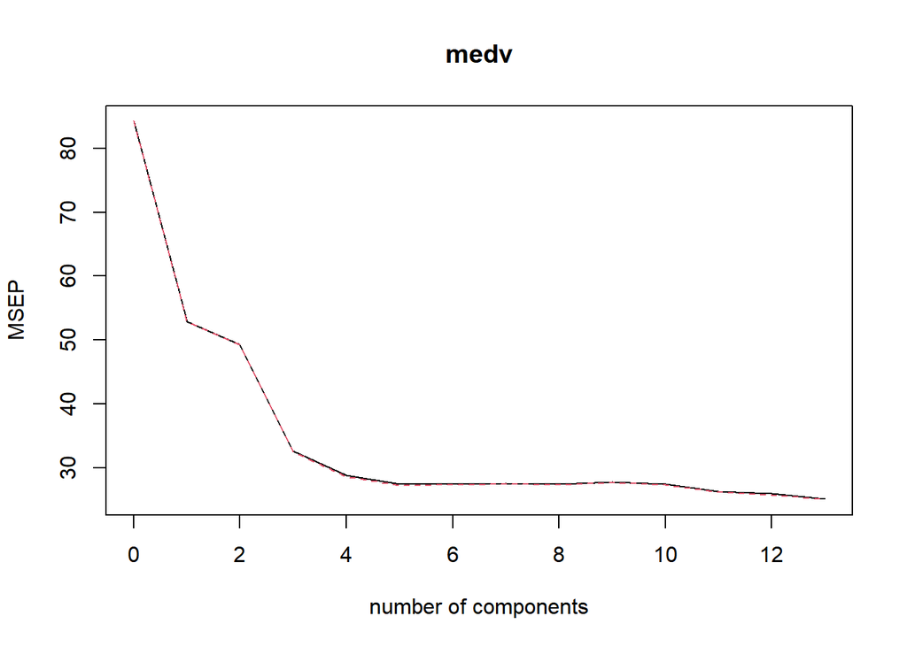

```r
validationplot(model,val.type = "MSEP")
```

```r
### Calculate Lowest MSE
pcr.pred = predict(model,test,ncomp=13)
mean((pcr.pred-y.test)^2)
```

```
## [1] 21.05844
```

```r
# MSE = 21.05844

### Test on whole Dataset
model.whole <- pcr(medv~.,data=Boston,scale=TRUE,validation="CV")
pcr.pred = predict(model.whole,test,ncomp=13)
mean((pcr.pred-y.test)^2)
```

```
## [1] 19.93409
```

```r
# MSE = 19.934

##### PLS
### Steps 1-3 Same as PCR
pls.fit <- plsr(medv~.,data=Boston,subset=training.indices, scale=TRUE,validation="CV")
summary(pls.fit)
```

```
## Data:    X dimension: 407 13
##  Y dimension: 407 1
## Fit method: kernelpls
## Number of components considered: 13
##
## VALIDATION: RMSEP
## Cross-validated using 10 random segments.
##        (Intercept)  1 comps  2 comps  3 comps  4 comps  5 comps  6 comps
## CV           9.179    6.613    5.124    5.025    4.968    4.931     4.91
## adjCV        9.179    6.608    5.117    5.018    4.958    4.921     4.90
##        7 comps  8 comps  9 comps  10 comps  11 comps  12 comps  13 comps
## CV       4.894    4.896    4.894     4.894     4.895     4.895     4.895
## adjCV    4.886    4.887    4.885     4.885     4.885     4.885     4.885
##
## TRAINING: % variance explained
##       1 comps  2 comps  3 comps  4 comps  5 comps  6 comps  7 comps  8 comps
## X       46.91    57.21    64.47    69.89    75.76    79.59    83.17    85.82
## medv    49.21    70.10    71.68    72.72    73.13    73.28    73.38    73.45
##       9 comps  10 comps  11 comps  12 comps  13 comps
## X       90.83     92.65     96.49     98.35    100.00
## medv    73.46     73.46     73.46     73.46     73.46
```

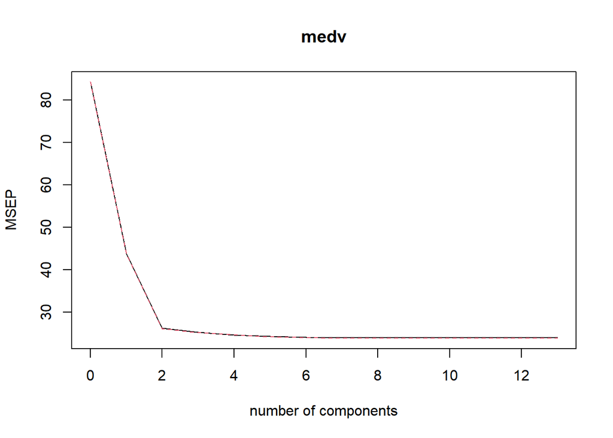

```r
validationplot(pls.fit,val.type="MSEP")
```

```r
pls.pred <- predict(pls.fit,test,ncomp=8)
mean((pls.pred-y.test)^2)
```

```
## [1] 20.95983
```

```r
# MSE = 20.95983

### Whole Dataset
pls.whole <- plsr(medv~.,data=Boston, scale=TRUE,validation="CV")
pls.pred <- predict(pls.whole,test,ncomp=8)
mean((pls.pred-y.test)^2)
```

```
## [1] 19.90098
```

```r
# MSE = 19.90098
```

## Polynomial Regression

Author: Carrington Metts

### Summary/description:

Polynomial regression fits a polynomial curve to a set of data. It is analagous to linear regression, but allows greater flexibility to fit to data that does not have a linear relationship.

### When to employ this method/model:

Polynomial regression should be used when there is a continuous response variable and one or more continuous features, and there is a nonlinear relationship between the X and Y variables.

Polynomial regression may also be used to estimate a binary response variable, given a set of continuous features.

### Model Code and Inputs:

A polynomial fit can be produced with either orthogonal or non-orthogonal terms. Having orthogonal polynomials means each term in the fit is a linear combination of each polynomial term (age^2, age^3, age^4, etc.) Non-orthogonal polynomials means the coefficients are reported directly. Both versions of orthogonality will result in the same fitted values. When creating models, **it is best to always use orthogonal terms**, since non-orthogonal terms are correlated with each other and therefore result in a multicollinearity problem.

As with linear regression, we use lm() or glm() to create the fit. Within lm() or glm(), the poly() function automatically creates orthogonal terms. (To create non-orthogonal terms, you can use the cbind() function, or set raw=True inside poly()). To create a model, we will use the Wage data (from ISLR) to predict wage as a function of age. We can then use coef() to get the coefficients of the model.

```r
library(ISLR)
#fit a degree-4 polynomial in 2 ways
orthogonal_fit <- lm(wage~poly(age,4), data=Wage)
summary(orthogonal_fit)
```

```
##
## Call:
## lm(formula = wage ~ poly(age, 4), data = Wage)
##
## Residuals:
##     Min      1Q  Median      3Q     Max
## -98.707 -24.626  -4.993  15.217 203.693
##
## Coefficients:
##                Estimate Std. Error t value Pr(>|t|)
## (Intercept)    111.7036     0.7287 153.283  < 2e-16 ***
## poly(age, 4)1  447.0679    39.9148  11.201  < 2e-16 ***
## poly(age, 4)2 -478.3158    39.9148 -11.983  < 2e-16 ***
## poly(age, 4)3  125.5217    39.9148   3.145  0.00168 **
## poly(age, 4)4  -77.9112    39.9148  -1.952  0.05104 .
## ---
## Signif. codes:  0 '***' 0.001 '**' 0.01 '*' 0.05 '.' 0.1 ' ' 1
##
## Residual standard error: 39.91 on 2995 degrees of freedom
## Multiple R-squared:  0.08626,    Adjusted R-squared:  0.08504
## F-statistic: 70.69 on 4 and 2995 DF,  p-value: < 2.2e-16
```

We can also create a polynomial logistic regression model to predict whether a person will earn more than $250,000. To do so, we use I() to coerce the continuous wage variable to binary categorical. We then run a glm fit on the model.

```r
logistic_fit <- glm(I(wage>250)~poly(age, 4), data=Wage, family=binomial)
```

### Model Tests:

It is important to choose the lowest-degree model that adequately models the data. To do so, we use the ANOVA (analysis of variance) test. ANOVA computes an F-test against two hypotheses: the null hypothesis, which states that a simple model is sufficient to explain the data, against a complex hypothesis, which states that a higher-order model is required.

To determine the best model for the Wage data, we will create 5 different polynomial models and run ANOVA.

```r
library(ISLR)
fit.1 <- lm(wage~age, data=Wage)
fit.2 <- lm(wage~poly(age,2), data=Wage)
fit.3 <- lm(wage~poly(age,3), data=Wage)
fit.4 <- lm(wage~poly(age,4), data=Wage)
fit.5 <- lm(wage~poly(age,5), data=Wage)

anova(fit.1, fit.2, fit.3, fit.4, fit.5)
```

```
## Analysis of Variance Table
##
## Model 1: wage ~ age
## Model 2: wage ~ poly(age, 2)
## Model 3: wage ~ poly(age, 3)
## Model 4: wage ~ poly(age, 4)
## Model 5: wage ~ poly(age, 5)
##   Res.Df     RSS Df Sum of Sq        F    Pr(>F)
## 1   2998 5022216
## 2   2997 4793430  1    228786 143.5931 < 2.2e-16 ***
## 3   2996 4777674  1     15756   9.8888  0.001679 **
## 4   2995 4771604  1      6070   3.8098  0.051046 .
## 5   2994 4770322  1      1283   0.8050  0.369682
## ---
## Signif. codes:  0 '***' 0.001 '**' 0.01 '*' 0.05 '.' 0.1 ' ' 1
```

Here, we see that the p-values for fits 2 and 3 are less than 0.05, which means the models are significant. However, the p-value for fit 4 is 0.051046. This means the fourth model is not significantly better than the third model. Therefore, we should use the third-order model.

The effectiveness of a polynomial regression model may be determined by R^2, MSE, or any other regression error metric. For polynomial logistic regression, we typically determine the output classes based on the predicted probabilities and compute the accuracy rate:

```r
predictedClasses = ifelse ( outputProb > .5, "Yes" , "No" )
table(predictedClasses, actualClasses)
```

### Model Predictions

#### Polynomial Regression

Now that we have chosen model 3, let’s use it to predict wage for some new list of ages. We’ll first create a new set of ages to feed to the model. Then, we’ll use the predict() function to calculate the predictions.

```r
agelims  = range(Wage$age) #pull out minimum and maximum ages
age.grid = seq(from=agelims[1], to=agelims[2]) #create a list of ages from the smallest to largest age
preds    = predict(fit.3, newdata=list(age=age.grid), se=TRUE) #make predictions on the new list of ages
```

Now, we want to determine the 95% confidence interval for our predictions, which corresponds to 2 standard deviations in each direction.

```r
se.bands = cbind(preds$fit+2*preds$se.fit, preds$fit-2*preds$se.fit)
```

We can now plot the data, prediction, and confidence interval:

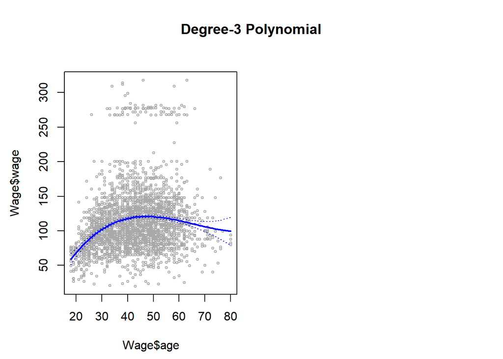

```r
par(mfrow=c(1,2), mar=c(4.5,4.5,1,1), oma=c(0,0,4,0))
plot(Wage$age, Wage$wage, xlim=agelims, cex =.5, col="darkgrey ") #data
title("Degree-3 Polynomial",outer=T)
lines(age.grid, preds$fit, lwd=2, col="blue") #predictions
matlines(age.grid, se.bands, lwd=1, col=" blue", lty=3) #confidence interval
```

#### Polynomial Logistic Regression

The glm() function automatically returns predictions in logit form, so we need to transform them to the actual values (ie probabilities that range from 0 to 1, as we expect). Other than that, the predictions and confidence intervals are computed and plotted in the same way.

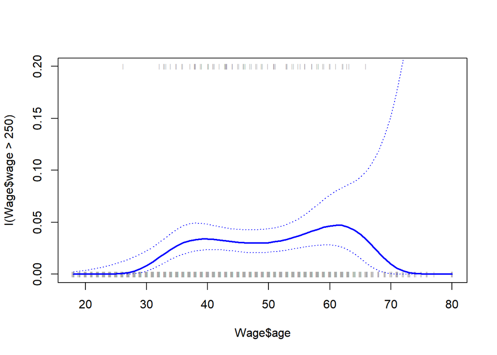

```r
logist_preds = predict(logistic_fit,newdata=list(age=age.grid),se=T) #make predictions

#transform predictions from logit form
pfit = exp(logist_preds$fit)/(1+exp(logist_preds$fit))

#compute confidence intervals and transform from logit form
se.bands.logit = cbind(logist_preds$fit +2* logist_preds$se.fit , logist_preds$fit -2*logist_preds$se.fit)
se.bands = exp(se.bands.logit)/(1+exp(se.bands.logit))

#plot data, fit, confidence band
plot(Wage$age ,I(Wage$wage >250),xlim=agelims ,type="n",ylim=c(0,.2)) #data

#add a jitter to the points so they don't overlap each other (just for aesthetics)
points(jitter(Wage$age), I((Wage$wage >250)/5),cex=.5,pch ="|", col="darkgrey")

#prediction
lines(age.grid ,pfit ,lwd=2, col ="blue")

#confidence interval
matlines (age.grid ,se.bands ,lwd=1, col="blue",lty=3)
```

### Comprehensive Example:

#### Polynomial Regression

```r
#run anova to pick best model (degree 1-5)
fit.1 <- lm(wage~age, data=Wage)
fit.2 <- lm(wage~poly(age,2), data=Wage)
fit.3 <- lm(wage~poly(age,3), data=Wage)
fit.4 <- lm(wage~poly(age,4), data=Wage)
fit.5 <- lm(wage~poly(age,5), data=Wage)

anova(fit.1, fit.2, fit.3, fit.4, fit.5)
```

```
## Analysis of Variance Table
##
## Model 1: wage ~ age
## Model 2: wage ~ poly(age, 2)
## Model 3: wage ~ poly(age, 3)
## Model 4: wage ~ poly(age, 4)
## Model 5: wage ~ poly(age, 5)
##   Res.Df     RSS Df Sum of Sq        F    Pr(>F)
## 1   2998 5022216
## 2   2997 4793430  1    228786 143.5931 < 2.2e-16 ***
## 3   2996 4777674  1     15756   9.8888  0.001679 **
## 4   2995 4771604  1      6070   3.8098  0.051046 .
## 5   2994 4770322  1      1283   0.8050  0.369682
## ---
## Signif. codes:  0 '***' 0.001 '**' 0.01 '*' 0.05 '.' 0.1 ' ' 1
```

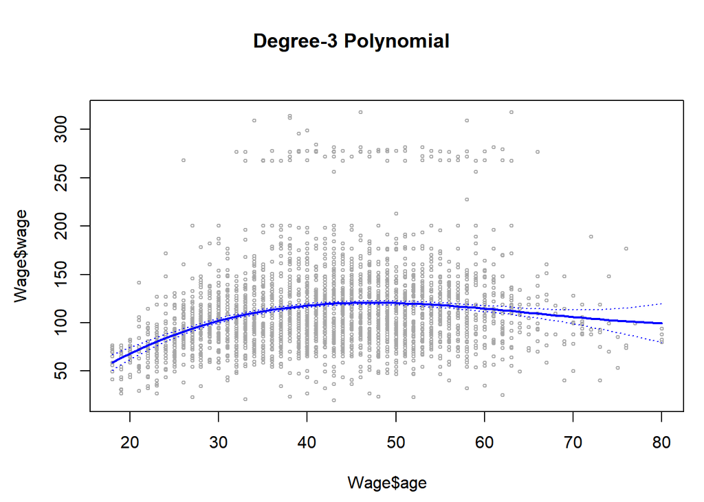

```r
#fit.3 is the best, according to anova
#create vector of new ages to make predictions on
agelims  = range(Wage$age)
age.grid = seq(from=agelims[1], to=agelims[2])

#make predictions
preds    = predict(fit.3, newdata=list(age=age.grid), se=TRUE)

#compute confidence interval
se.bands = cbind(preds$fit+2*preds$se.fit, preds$fit-2*preds$se.fit)

#plot data, fit, 95% confidence interval
par(mfrow=c(1,1), mar=c(4.5,4.5,1,1), oma=c(0,0,4,0))
plot(Wage$age, Wage$wage, xlim=agelims, cex =.5, col="darkgrey ") #data
title("Degree-3 Polynomial",outer=T)
lines(age.grid, preds$fit, lwd=2, col="blue") #fit
matlines(age.grid, se.bands, lwd=1, col=" blue", lty=3) #confidence interval
```

#### Polynomial Logistic Regression

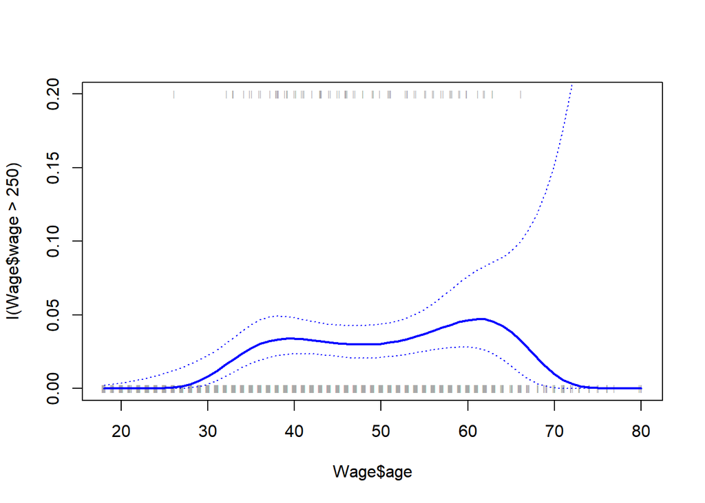

```r
#create the model
logistic_fit <- glm(I(wage>250)~poly(age, 4), data=Wage, family=binomial)

#make predictions for new data (returns probabilities in logit form)
logist_preds = predict(logistic_fit,newdata=list(age=age.grid),se=T)

#transform probabilities from logit form to normal (ie probabilities that go from 0 to 1, as we expect)
pfit = exp(logist_preds$fit)/(1+exp(logist_preds$fit))

#find the 2-standard-deviation confidence intervals
se.bands.logit = cbind(logist_preds$fit +2* logist_preds$se.fit , logist_preds$fit -2*logist_preds$se.fit)

#transform confidence intervals from logit to normal form
se.bands = exp(se.bands.logit)/(1+exp(se.bands.logit))

#plot the data points, apply a jitter so they aren't on top of each other
plot(Wage$age ,I(Wage$wage >250),xlim=agelims ,type="n",ylim=c(0,.2))
points(jitter(Wage$age), I((Wage$wage >250)/5),cex=.5,pch ="|", col="darkgrey")

#plot the predicted values (age.grid and the Y predictions)
lines(age.grid ,pfit ,lwd=2, col ="blue")

#plot the confidence intervals
matlines (age.grid ,se.bands ,lwd=1, col="blue",lty=3)
```

## Step Functions

Author: Alex Russett

### Summary and Description

In general **step functions** allow you to fit different areas of your data to different constant functions that will allow them to fit the data better overall. This is stated in the book as avoiding imposing a **global structure** on data, and to instead break the data into **bins**, allowing us to fit a different constant to each bin.

To do this, we create cut points C(1), C(2)… ,C(k) in the range of X, then construct K+! new variables.

You can see example pictures on page 269 in chapter 7.2 of ISLR

### When do we use step functions?

Step functions should ONLY be used when there are very natural and easy to identify break points in the X range of the data. They are commonly used with categorical features.

Step Functions are commonly used among Neural Networks as well.

### Model Code and Inputs:

#### Basics - Sample code not designed to be run

```r
# Fitted Step function
lm(Y ~ cut(X,4))
# Fitted Logistic Regression
glm(Y ~ cut(X,4))
```

The above code chunk is choosing the data, and then the number of splits to employ! This is the entire applicaiton of the step function.

Here it is in context!

### Full Comprehensive Example

This example uses an LM function, but I will highlight when it fits a step function for analysis!

```r
# Load library and attach data set
rm(list=ls())
library(ISLR)
attach(Wage)
```

```r
#using the lm() function, in order to predict
#wage using a fourth-degree polynomial in age: poly(age,4). The poly() command allows us to avoid having to write out a long formula with powers of age.
fit=lm(wage~poly(age ,4) ,data=Wage)
coef(summary(fit))
```

```
##                 Estimate Std. Error    t value     Pr(>|t|)
## (Intercept)    111.70361  0.7287409 153.283015 0.000000e+00
## poly(age, 4)1  447.06785 39.9147851  11.200558 1.484604e-28
## poly(age, 4)2 -478.31581 39.9147851 -11.983424 2.355831e-32
## poly(age, 4)3  125.52169 39.9147851   3.144742 1.678622e-03
## poly(age, 4)4  -77.91118 39.9147851  -1.951938 5.103865e-02
```

```r
#We can use poly() to obtain age, age^2, age^3, and age^4, if we prefer. We do this by adding the raw=TRUE argument to the poly() function
fit2 = lm(wage~poly(age,4,raw=T),data=Wage)
coef(summary(fit2))
```

```
##                             Estimate   Std. Error   t value     Pr(>|t|)
## (Intercept)            -1.841542e+02 6.004038e+01 -3.067172 0.0021802539
## poly(age, 4, raw = T)1  2.124552e+01 5.886748e+00  3.609042 0.0003123618
## poly(age, 4, raw = T)2 -5.638593e-01 2.061083e-01 -2.735743 0.0062606446
## poly(age, 4, raw = T)3  6.810688e-03 3.065931e-03  2.221409 0.0263977518
## poly(age, 4, raw = T)4 -3.203830e-05 1.641359e-05 -1.951938 0.0510386498
```

```r
# There are a few other ways to fit the model, showing the flexibility of the formula language in R:
fit2a = lm(wage~age+I(age^2)+I(age^3)+I(age^4),data=Wage)
coef(fit2a)
```

```
##   (Intercept)           age      I(age^2)      I(age^3)      I(age^4)
## -1.841542e+02  2.124552e+01 -5.638593e-01  6.810688e-03 -3.203830e-05
```

```r
fit2b = lm(wage~cbind(age,age^2,age^3,age^4),data=Wage)
coef(fit2b)
```

```
##                        (Intercept) cbind(age, age^2, age^3, age^4)age
##                      -1.841542e+02                       2.124552e+01
##    cbind(age, age^2, age^3, age^4)    cbind(age, age^2, age^3, age^4)
##                      -5.638593e-01                       6.810688e-03
##    cbind(age, age^2, age^3, age^4)
##                      -3.203830e-05
```

```r
#We now create a grid of values for age at which we want predictions, and then call the generic predict() function, specifying that we want standard errors as well
agelims =range(age)
age.grid=seq(from=agelims [1],to=agelims [2])
preds=predict (fit ,newdata =list(age=age.grid),se=TRUE)
se.bands=cbind(preds$fit +2* preds$se.fit,preds$fit -2* preds$se.fit)
```

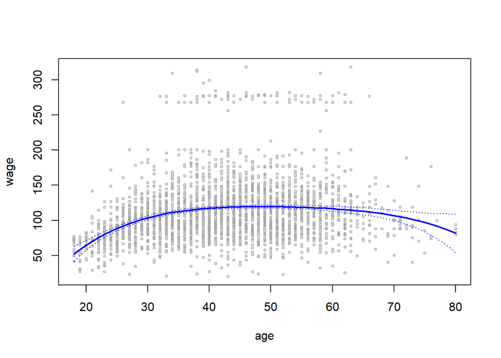

```r
#Finally, we plot the data and add the fit from the degree-4 polynomial:
plot(age ,wage ,xlim=agelims ,cex =.5,col=" darkgrey ")
lines(age.grid ,preds$fit,lwd=2,col="blue")
matlines(age.grid ,se.bands ,lwd=1, col=" blue",lty=3)
```

```r
#To determine the simplest model which is sufficient to explain the relationship between wage and age we fit 5 models of increasing polynomial degrees:
fit.1 =lm(wage~age,data=Wage)
fit.2 =lm(wage~poly(age,2),data=Wage)
fit.3 =lm(wage~poly(age,3),data=Wage)
fit.4 =lm(wage~poly(age,4),data=Wage)
fit.5 =lm(wage~poly(age,5),data=Wage)
anova(fit.1, fit.2, fit.3, fit.4, fit.5)
```

```
## Analysis of Variance Table
##
## Model 1: wage ~ age
## Model 2: wage ~ poly(age, 2)
## Model 3: wage ~ poly(age, 3)
## Model 4: wage ~ poly(age, 4)
## Model 5: wage ~ poly(age, 5)
##   Res.Df     RSS Df Sum of Sq        F    Pr(>F)
## 1   2998 5022216
## 2   2997 4793430  1    228786 143.5931 < 2.2e-16 ***
## 3   2996 4777674  1     15756   9.8888  0.001679 **
## 4   2995 4771604  1      6070   3.8098  0.051046 .
## 5   2994 4770322  1      1283   0.8050  0.369682
## ---
## Signif. codes:  0 '***' 0.001 '**' 0.01 '*' 0.05 '.' 0.1 ' ' 1
```

We use the anova() function, which performs an analysis of variance (ANOVA, using an F-test) in order to test the null analysis of hypothesis that a model M1 is sufficient to explain the data against the variance alternative hypothesis that a more complex model M2 is required.

```r
#Now we want to try to predict if an individual is making more than $250,000 per year:
fit = glm(I(wage>250)~poly(age,4), data=Wage, family=binomial)

#The expression wage > 250 evaluates to a logical variable of TRUE's and FALSE's, which are turned into 1's and 0's

preds = predict(fit,newdata=list(age=age.grid),se=T)


#The default prediction type for a glm() model is type="link", which is what we use here. This means we get predictions
#of the logit, so some transformations need to be done to obtain the correct confidence interval
pfit = exp(preds$fit)/(1+exp(preds$fit))
se.bands.logit=cbind(preds$fit + 2*preds$se.fit, preds$fit - 2*preds$se.fit)
se.bands = exp(se.bands.logit)/(1+exp(se.bands.logit))
```

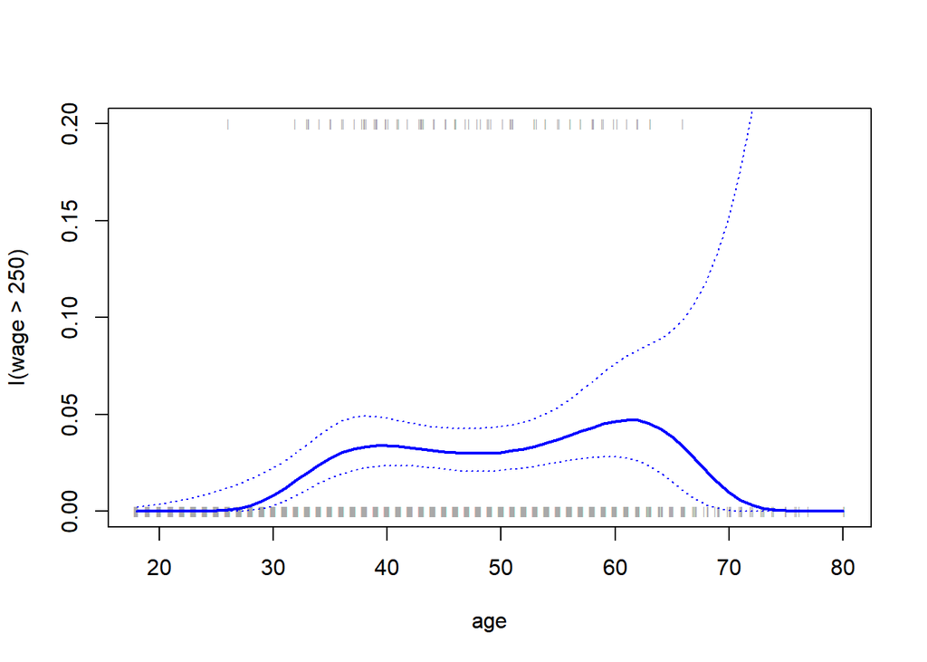

```r
#To complete the right-hand side plot of figure 7.1:
plot(age,I(wage>250), xlim=agelims, type="n", ylim=c(0,.2))
points(jitter(age), I((wage>250)/5), cex=.5, pch="|", col="darkgrey")
lines(age.grid, pfit, lwd=2, col="blue")
matlines(age.grid, se.bands, lwd=1, col="blue", lty=3)
```

### Step Function Implementation

```r
table(cut(age,4))
```

```
##
## (17.9,33.5]   (33.5,49]   (49,64.5] (64.5,80.1]
##         750        1399         779          72
```

```r
fit=lm(wage~cut(age,4),data=Wage)
coef(summary(fit))
```

```
##                         Estimate Std. Error   t value     Pr(>|t|)
## (Intercept)            94.158392   1.476069 63.789970 0.000000e+00
## cut(age, 4)(33.5,49]   24.053491   1.829431 13.148074 1.982315e-38
## cut(age, 4)(49,64.5]   23.664559   2.067958 11.443444 1.040750e-29
## cut(age, 4)(64.5,80.1]  7.640592   4.987424  1.531972 1.256350e-01
```

### Results and Final Thoughts

The function automatically chose breakpoints of 33.5, 49, and 64.5 years, but we could have chosen our own bins with the “breaks” option when splitting the data into bins.

The cut() function returns an ordered categorical variable, which the lm() function then uses to create dummy variables to regress upon.

Age less than 33.5 is left out, and the result of that intercept is the average salary for those under 33.5 years old.

## Regression Splines

Author: Andrew Tremblay & Thomas Trankle

### Summary/description:

**Regression Splines** are more flexible than polynomials and step functions.

This is because the are actually an extension of the two.

They involve dividing the range of *X* into *K* distinct regions. Within each region, a polynomial function is fit to the data. However, these polynomials are constrained so that they **join smoothly at the region boundaries, or knots**. Provided that the interval is divided into enough regions, this can produce an extremely flexible fit.

The points where the coefficients change are called *knots*.

In general, if we place *K* different knots throughout the range of *X*, then we will end up fitting *K + 1* different polynomials.

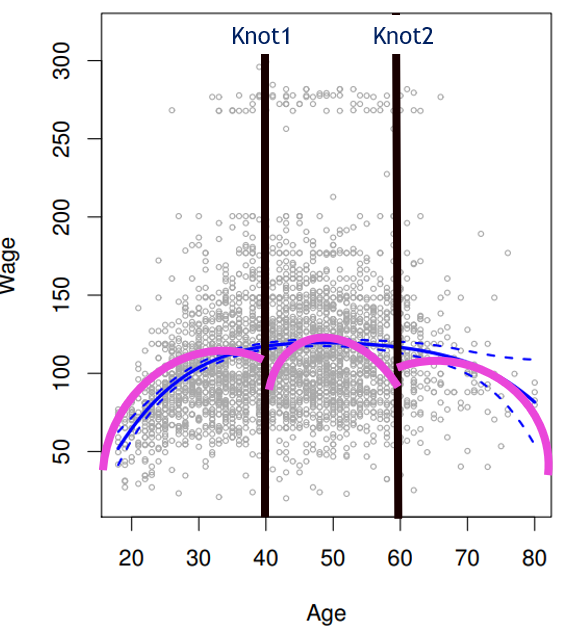

To make it a continuous function we add constraints to the model. Each constraint that we impose on the piecewise polynomials effectively frees up one degree of freedom.

Remember, there are degrees of freedom for the entire model(Total DF) and the specified degrees of freedom for the polynomial (df).
$$df = degree + knots$$

```r
# Using the bs() function deals with the formula above
bs(x , df = NULL, knots = NULL, degree = 3 #default
   intercept = False)
```

$$\textit{Total DF} = 1 + df = 1 + degree + knots$$

### When to employ this method/model:

Instead of fitting a high-degree polynomial over the entire range of *X*, *piecewise polynomial regression* involves fitting separate low-degree polynomials over different regions of *X*.

We use this model when we need a high degree of flexibility.

Using more knots leads to a more flexible piecewise polynomial.

### Model Code and Inputs:

```r
library(ISLR)
library(splines)
library(boot)
```

To generate a regression spline, we use the bs() function from the *spline* package.

```r
# To ensure the data is inputted, we advise attaching the data
attach(Wage)

# generally, we need to either specify the df or number of knots
#bs(age, df = NULL, knots = NULL, degree = 3, intercept = FALSE,
#   Boundary.knots = range(x))

# The following code outlines fitting wage to age using a regression spline
# by defining the number of knots
regression.spline <- glm(wage ~ bs(age,
                                 knots=c(25,40,60))) #knot argument specifies
                                                     #specific knot locations
                                                     # on axis

# If you don't know where to create the knots but know you want 3 knots in your
# model, then specify df and knot locations will be automatically generated.
regression.spline <- glm(wage~bs(age, df = 6)) #6 was used as default degree = 3
                                               # df = degree + knots
                                               # 6= 3 + knots

#You cannot use knots to specify number of knots directly
# lm(Y ~ bs(X, knots=3) # error – will not give you 3 knots

# The Total DF for this model is 7
```

### Model Tests:

What is the best degree for our polynomial and how many knots should we use, or equivalently how many degrees of freedom should our spline contain? One option is to try out different numbers of knots and see which produces the best looking curve. A somewhat more objective approach is to use cross-validation.

There are two steps for this.

1.) Polynomial degree determination for our data using CV

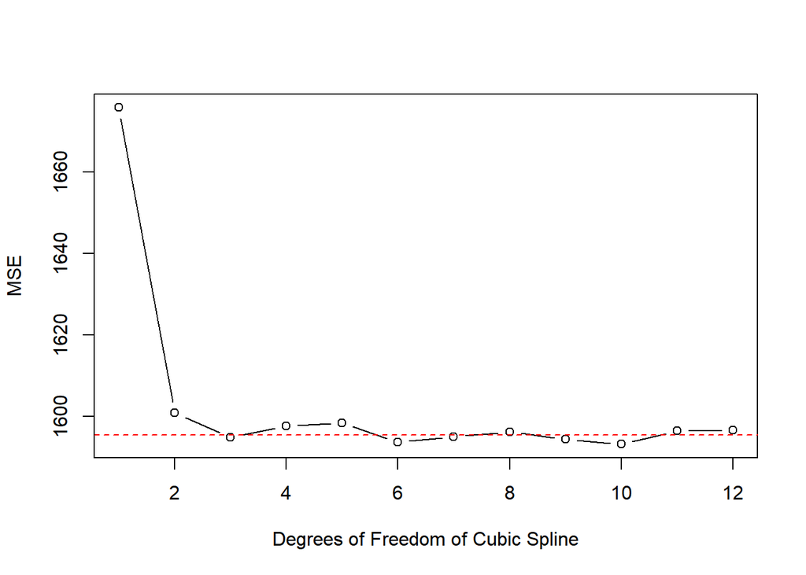

```r
mse.error <- rep(0,12)
set.seed(5082)
for (i in 1:12){
  regSpline <- glm(wage ~ bs(age, degree = i), data = Wage)
  mse.error[i] <- cv.glm(Wage, regSpline, K=10)$delta[1]
}

plot(mse.error, xlab = 'Degrees of Freedom of Cubic Spline',ylab = 'MSE')
lines(mse.error, type = 'b',lty = 1)
stdev <- sd(mse.error[2:12])
abline(h= min(mse.error) + stdev, col = "red", lty = "dashed")
```

2.) Now we can use the best degree found above, determine the correct number of knots, if any.

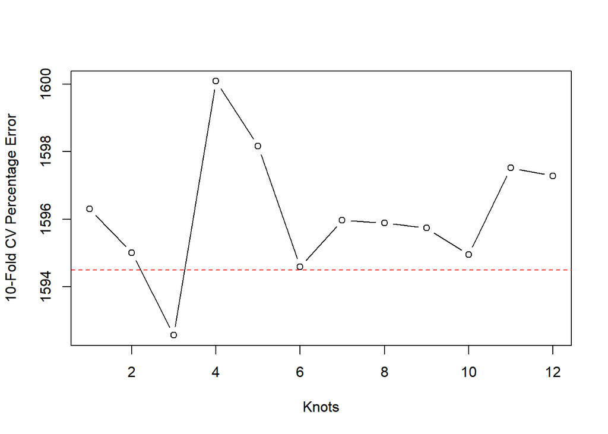

```r
error.vector <- rep(0,12) # create an error vector to store cv results

set.seed(5082)
for (i in 3:14 ){
  regression.spline <- glm(wage ~ bs(age, df = i, degree= 3))
  error.vector[i-2] <- cv.glm(Wage, regression.spline, K = 10)$delta[1] #The default is the average squared error function.(MSE)
}

# Plot Results

plot(error.vector, xlab = 'Knots',ylab = '10-Fold CV Percentage Error')
lines(error.vector, type = 'b',lty = 1)
stdev <- sd(error.vector[1:12])
abline(h= min(error.vector) + stdev, col = "red", lty = "dashed")
```

So, for a degree-3 polynomial we will choose 2 knots because this is the most simple model whose CV error, for knots, lies within 1 SD error of the lowest cross validation error point.

### Comprehensive Example:

AUTO DATA

```r
library(ISLR)
attach(Auto)
error.vector.degree <- rep(0,10)
set.seed(111)
# First determine appropriate polynomial degree
for (i in 1:10 ){
  regression.spline <- glm(acceleration ~ bs(weight, degree = i), data = Auto)
  error.vector.degree[i] <- cv.glm(Auto, regression.spline, K=10)$delta[1]
}
```

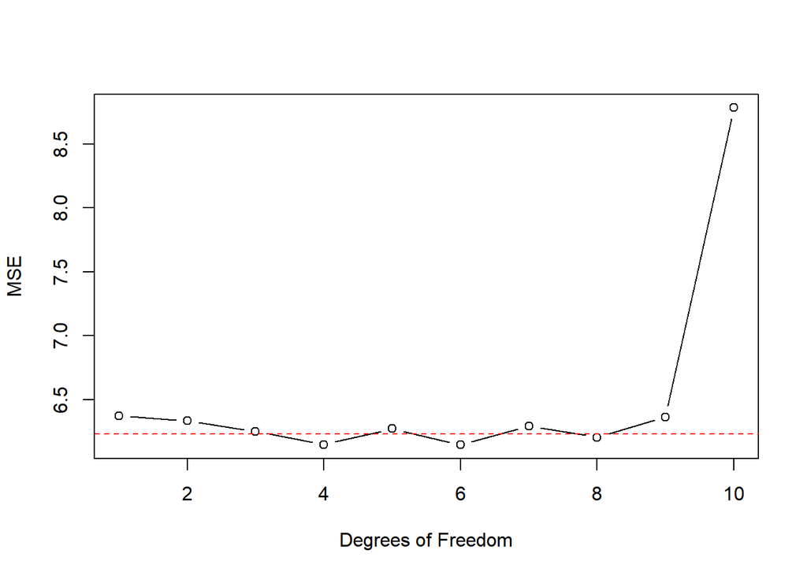

```r
plot(error.vector.degree, xlab = 'Degrees of Freedom',ylab = 'MSE')
lines(error.vector.degree, type = 'b',lty = 1)
stdev <- sd(error.vector.degree[1:9])
abline(h= min(error.vector.degree) + stdev, col = "red", lty = "dashed")
```

We examine the best degree for our model is 4.

```r
error.vector.knots <- rep(0,10) # create an error vector to store cv results

set.seed(222)
for (i in 1:10 ){
  regression.spline <- glm(acceleration ~ bs(weight, df = i + 3,degree = 4))
  error.vector.knots[i] <- cv.glm(Auto, regression.spline, K = 10)$delta[1]
}
```

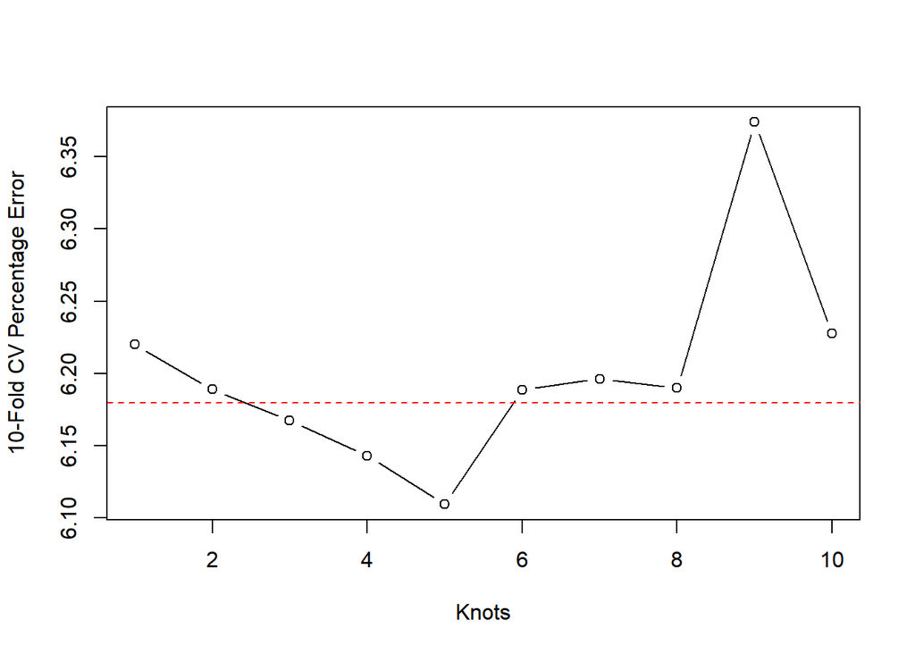

```r
# Plot Results

plot(error.vector.knots, xlab = 'Knots',ylab = '10-Fold CV Percentage Error')
lines(error.vector.knots, type = 'b',lty = 1)
stdev <- sd(error.vector.knots[1:10])
abline(h= min(error.vector.knots) + stdev, col = "red", lty = "dashed")
```

We get two Knots!!!! Since the actual knots = Knots (x-axis) - 1